# Neural Network - Street View House Number (SVHN)

## Description

The goal of this hands-on project is to build a classifier model from scratch to understand the nitty gritties of building and training a model and further to understand the advantages of neural networks. First we will implement a simple KNN classifier and later implement a Neural Network to classify the images in the SVHN dataset. We will compare the computational efficiency and accuracy between the traditional method (k-Nearest Neighbor) and neural networks.

## Dataset Information

The **Street View House Number (SVHN)** dataset is a real-world image dataset for developing machine learning and object recognition algorithms with minimal requirement on data formatting but comes from a significantly harder, unsolved, real world problem (recognizing digits and numbers in natural scene images). SVHN is obtained from house numbers in Google Street View images.

SVHN identification is a difficult problem. The main challenges are often decomposed into three subproblems: (i) finding the number on the house, (ii) segmenting the individual digits, and (iii) classifying the digits. Each of these subproblems is difficult, for different reasons. Localization is a challenge because numbers are hard to distinguish from other shapes; segmentation is difficult because the digits are often close together (and sometimes even connected); and classification is difficult because there is a massive variety in the typefaces, textures and colours present in house numbers.

We'll be working on the 3rd format of the problem which is to classify 32x32 images centered around a single character (many of the images do contain some distractors at the sides).

## Imports and Configurations

```python
# Utilities
import sys
import h5py
import warnings
from time import time

# Numerical calculation
import numpy as np

# Data handling
import pandas as pd

# Data Visualization
import matplotlib.pyplot as plt
import seaborn as sns

# Conventional ML Model
from sklearn.neighbors import KNeighborsClassifier
from sklearn.model_selection import train_test_split
from sklearn.metrics import accuracy_score, confusion_matrix, classification_report

# Neural Network
from tensorflow.keras import utils, losses, optimizers, callbacks
from tensorflow.keras.models import Sequential
from tensorflow.keras.layers import Dropout, ReLU, Dense, BatchNormalization
```

```python
# Configure for any default setting of any library
np.random.seed(5)
warnings.filterwarnings('ignore')
%matplotlib inline
pd.set_option('display.float_format', lambda x: '%.3f' % x)
```

## Load and Visualize the Data

This notebook is made generic to run in both Google Colab and in local workstation. Load the h5 file and visualize the data in it.

```python
svhn_file = 'SVHN_single_grey1.h5'
if 'google.colab' in sys.modules:
    # Google Colab lib
    from google.colab import drive
    # Mount the drive
    drive.mount('/content/drive/')
    # Open the drive file as readonly
    svhn = h5py.File('/content/drive/My Drive/Colab Notebooks/DLCP/' + svhn_file, 'r')
else:
    # Open the local file as readonly
    svhn = h5py.File(svhn_file, 'r')
```

```python
# Load the training, validation and test sets
X_train_o = svhn['X_train'][:]
X_test_o = svhn['X_test'][:]
X_val_o = svhn['X_val'][:]
y_train_o = svhn['y_train'][:]
y_test_o = svhn['y_test'][:]
y_val_o = svhn['y_val'][:]

print('Shape of different datasets are:')
print('X_train :', X_train_o.shape)
print('X_test  :', X_test_o.shape)
print('X_val   :', X_val_o.shape)
print('y_train :', y_train_o.shape)
print('y_test  :', y_test_o.shape)
print('y_val   :', y_val_o.shape)
```

```
Shape of different datasets are:
X_train : (42000, 32, 32)
X_test  : (18000, 32, 32)
X_val   : (60000, 32, 32)
y_train : (42000,)
y_test  : (18000,)
y_val   : (60000,)
```

```
Labels corresponding to below images: [2 6 7 4 4 0 3 0 7 3 1 0 1 3 1]
```

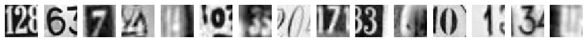

```python
# visualizing the first 15 images in the dataset and their labels
print('Labels corresponding to below images: %s' % (y_train_o[0:15]))
plt.figure(figsize=(15, 1))
for i in range(15):
    plt.subplot(1, 15, i+1)
    plt.imshow(X_train_o[i], cmap="gray")
    plt.axis('off')
```

## Preprocess the Image

The images are gray-scaled images with 32x32 pixels each of 1 byte in size. So the values containing in each pixel ranges from $0$ to $2^8-1 = 255$. In order to feed them into Neural Network we must convert the input matrix to 1-D vector. Hence as part of this preprocessing step, we will do the following

- Flatteing
- Normalization

```python
# Flatten the X_* datasets
X_train_f = X_train_o.reshape(X_train_o.shape[0], X_train_o.shape[1] * X_train_o.shape[2]).astype('float32')
X_test_f = X_test_o.reshape(X_test_o.shape[0], X_test_o.shape[1] * X_test_o.shape[2]).astype('float32')
X_val_f = X_val_o.reshape(X_val_o.shape[0], X_val_o.shape[1] * X_val_o.shape[2]).astype('float32')

print('Shape after flattening:')
print('X_train :', X_train_f.shape)
print('X_test  :', X_test_f.shape)
print('X_val   :', X_val_f.shape)
```

```
Shape after flattening:
X_train : (42000, 1024)
X_test  : (18000, 1024)
X_val   : (60000, 1024)
```

```python
# Normalize the inputs from 0-255 to 0-1
X_train = X_train_f / 255.0
X_test = X_test_f / 255.0
X_val = X_val_f / 255.0

print(X_train)
```

```
[[0.12968785 0.11866706 0.10530196 ... 0.19477727 0.19942354 0.20799099]
 [0.34101608 0.3414451  0.34656274 ... 0.29498273 0.30054745 0.31092745]
 [0.48284313 0.49356118 0.47872823 ... 0.36837214 0.41093138 0.44637334]
 ...
 [0.6042902  0.61100274 0.6149663  ... 0.52993256 0.53592    0.5398412 ]
 [0.8137075  0.8176286  0.8353796  ... 0.83974785 0.8319055  0.820142  ]
 [0.37285647 0.37677765 0.39246237 ... 0.5414914  0.5509529  0.5509529 ]]
```

## Understand the target classes

Let's understand diversity, datatypes and distribution of the target classes.

```python
# Get unique values in target sets
np.unique(y_train_o)
np.unique(y_test_o)
np.unique(y_val_o)
```

```
array([0, 1, 2, 3, 4, 5, 6, 7, 8, 9], dtype=uint8)
```

All datasets contain unsigned int8 type target class values 0-9. Let's convert them into categorical and check their distribution.

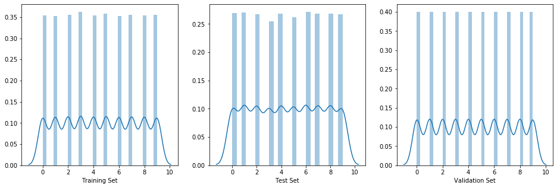

```python
fig, axes = plt.subplots(1, 3, figsize=(16,5))
sns.distplot(y_train_o, ax=axes[0], axlabel='Training Set')
sns.distplot(y_test_o, ax=axes[1], axlabel='Test Set')
sns.distplot(y_val_o, ax=axes[2], axlabel='Validation Set')
```

```python
# Apply One-Hot-Encoding
y_train = utils.to_categorical(y_train_o)
y_test = utils.to_categorical(y_test_o)
y_val = utils.to_categorical(y_val_o)

print('Shape of different target sets are:')
print('y_train :', y_train.shape)
print('y_test  :', y_test.shape)
print('y_val   :', y_val.shape)
```

```
Shape of different target sets are:
y_train : (42000, 10)
y_test  : (18000, 10)
y_val   : (60000, 10)
```

## k-Nearest Neighbor Model

We will now consider a subset of the data for KNN classification. K Nearest neighbours classification is a traditional ML model building. We will analyze it is pertinence in the context of OCR.

```python
# Take a subset of the original dataset to estimate for the best k
X_train_sub = X_train[:3000]
y_train_sub = y_train_o[:3000]
X_test_sub = X_test[:1000]
y_test_sub = y_test_o[:1000]
```

```python
# Find accuracy scores for 30 iterations
st = time()
acc_scores = []
for k in range(1,31):
    knn = KNeighborsClassifier(n_neighbors=k , weights='uniform', metric='euclidean')
    knn.fit(X_train_sub, y_train_sub)
    acc_scores.append(accuracy_score(y_test_sub, knn.predict(X_test_sub)) * 100)

print('Time taken:', time()-st)
print('Scores out of 30 iterations:', np.round(acc_scores, 1))
```

```
Time taken: 154.16272807121277
Scores out of 30 iterations: [32.1 30.7 30.7 33.6 33.3 33.6 32.8 34.4 34.6 34.3 34.5 34.6 34.4 35.4
 34.7 35.8 35.4 35.5 35.  34.8 34.8 34.  33.3 34.1 33.5 33.2 33.6 33.2
 33.2 33.1]
```

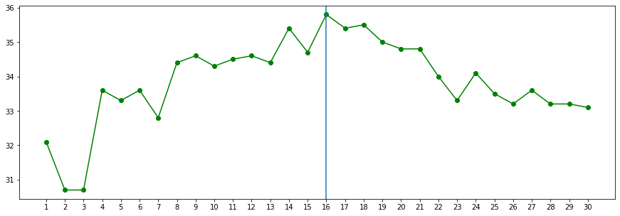

```python
# Plot the accuracy scores
plt.figure(figsize=(15,5))
plt.plot(range(1,31), acc_scores , '-go')
_ = plt.xticks(range(1,31))
plt.axvline(np.argmax(acc_scores) + 1)
```

The accuracy score seems to be the best at 35.8% for k value of 16. Let's set the k value to 16 and train a model with the entire training dataset.

```python
# Create the classifier model using the best k found among 30 iterations
st = time()
clf = KNeighborsClassifier(n_neighbors= np.argmax(acc_scores) + 1)
clf.fit(X_train, y_train_o)

predictions = clf.predict(X_test)
print('Time taken:', time()-st)
```

```
Time taken: 1582.1469604969025
```

```python
# Classification Report
print("EVALUATION ON TESTING DATA")
print(classification_report(y_test_o, predictions))
```

```
EVALUATION ON TESTING DATA
              precision    recall  f1-score   support

           0       0.44      0.69      0.54      1814
           1       0.47      0.73      0.57      1828
           2       0.61      0.55      0.58      1803
           3       0.45      0.43      0.44      1719
           4       0.66      0.65      0.65      1812
           5       0.51      0.39      0.44      1768
           6       0.49      0.41      0.44      1832
           7       0.71      0.62      0.66      1808
           8       0.46      0.36      0.40      1812
           9       0.56      0.42      0.48      1804

    accuracy                           0.53     18000
   macro avg       0.54      0.52      0.52     18000
weighted avg       0.54      0.53      0.52     18000
```

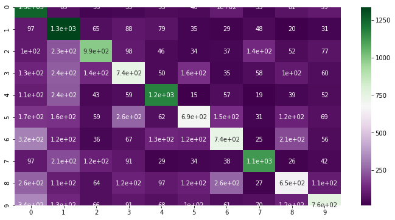

```python
# Visualize the Confusion Matrix
plt.figure(figsize=(12,6))
sns.heatmap(confusion_matrix(y_test_o, predictions), annot=True, cmap="PRGn")
```

**Observations:**

## Neural Network Model

A Neural Network, unlike traditional ML algorithms, is a series of algorithms that endeavors to recognize underlying relationships in a set of data through a process that mimics the way the human brain operates. Neural networks can adapt to changing input; so the network generates the best possible result without needing to redesign the output criteria.

Let's define a generic method to architect the network based on a layers array.

```python
# Generic method to Build the Neural Network
def NNModel(layers):
    # Create model
    network = Sequential()
    # Add the layers
    if layers:
        for layer in layers:
            network.add(layer['layer_type'](**layer['params']))
    return network
```

#### Initialize Tensorboard callback for visualization of training

```python
# Setting the directory to store the log file
# tb_callback = callbacks.TensorBoard(log_dir='.logs/{}'.format(time()),
#                                     histogram_freq=0,
#                                     write_graph=True,
#                                     write_images=True)
```

#### Initialize Early Stopping and Model Checkpoint callbacks

```python
# Stop if the val_loss is not changing even 0.001 for more than 10 continious epochs
es_callback = callbacks.EarlyStopping(monitor='val_loss',
                                      min_delta=0.001,
                                      patience=10)

# Saving the best weights - Saves the weights when the val_loss achieves a new low value
# mc_callback = callbacks.ModelCheckpoint('SVHN_checkpoint_{epoch:02d}_loss{val_loss:.4f}.h5',
#                                         monitor='val_loss',
#                                         verbose=1,
#                                         save_best_only=True,
#                                         mode='auto')
```

## Iteration - 1

Learning Rate: 0.005  
Momentum: 0.02  
Epochs: 30  
Batch Size: 200  
Optimizer: SGD  
Loss: Categorical Crossentropy

#### Define the Layers

```python
# Define the layers for Iteration - 1
layers = [
    {
        'layer_type': Dense,
        'params': {
            'units': 256,
            'activation': 'relu'
        }
    },{
        'layer_type': Dense,
        'params': {
            'units': 64,
            'activation': 'relu'
        }
    },{
        'layer_type': Dense,
        'params': {
            'units': 64,
            'activation': 'relu'
        }
    },{
        'layer_type': Dense,
        'params': {
            'units': len(np.unique(y_train_o)),
            'activation': 'softmax'
        }
    }
]

# Build network architecture
model1 = NNModel(layers)
```

#### Set Optimizer and Loss function for training

```python
learning_rate = 5e-3
momentum = 2e-2

# Optimizer = SGD, Loss function = Categorical cross entropy
model1.compile(optimizer = optimizers.SGD(learning_rate, momentum),
              loss = losses.categorical_crossentropy,
              metrics=['accuracy'])
```

#### Train the network

```python
epochs = 30
batch_size = 200

# Start training the network
st = time()
model1.fit(X_train, y_train,
          validation_data=(X_val, y_val),
          epochs=epochs,
          batch_size=batch_size,
          verbose=2,
          callbacks=[es_callback])
print('\nTotal time taken:', time()-st)
```

```
Train on 42000 samples, validate on 60000 samples
42000/42000 - 2s - loss: 2.3041 - accuracy: 0.1050 - val_loss: 2.2966 - val_accuracy: 0.1191
42000/42000 - 2s - loss: 2.2935 - accuracy: 0.1311 - val_loss: 2.2902 - val_accuracy: 0.1540
42000/42000 - 2s - loss: 2.2873 - accuracy: 0.1607 - val_loss: 2.2841 - val_accuracy: 0.1767
42000/42000 - 2s - loss: 2.2808 - accuracy: 0.1758 - val_loss: 2.2776 - val_accuracy: 0.1929
42000/42000 - 2s - loss: 2.2727 - accuracy: 0.1916 - val_loss: 2.2688 - val_accuracy: 0.2041
42000/42000 - 2s - loss: 2.2641 - accuracy: 0.2033 - val_loss: 2.2595 - val_accuracy: 0.2122
42000/42000 - 2s - loss: 2.2542 - accuracy: 0.2176 - val_loss: 2.2496 - val_accuracy: 0.2130
42000/42000 - 2s - loss: 2.2431 - accuracy: 0.2319 - val_loss: 2.2367 - val_accuracy: 0.2474
42000/42000 - 2s - loss: 2.2294 - accuracy: 0.2452 - val_loss: 2.2225 - val_accuracy: 0.2490
42000/42000 - 2s - loss: 2.2133 - accuracy: 0.2629 - val_loss: 2.2043 - val_accuracy: 0.2654
42000/42000 - 2s - loss: 2.1936 - accuracy: 0.2823 - val_loss: 2.1823 - val_accuracy: 0.2840
42000/42000 - 2s - loss: 2.1698 - accuracy: 0.2968 - val_loss: 2.1570 - val_accuracy: 0.3103
42000/42000 - 2s - loss: 2.1426 - accuracy: 0.3196 - val_loss: 2.1291 - val_accuracy: 0.3300
42000/42000 - 2s - loss: 2.1113 - accuracy: 0.3344 - val_loss: 2.0954 - val_accuracy: 0.3436
42000/42000 - 2s - loss: 2.0757 - accuracy: 0.3527 - val_loss: 2.0564 - val_accuracy: 0.3578
42000/42000 - 2s - loss: 2.0364 - accuracy: 0.3672 - val_loss: 2.0153 - val_accuracy: 0.3755
42000/42000 - 2s - loss: 1.9936 - accuracy: 0.3821 - val_loss: 1.9709 - val_accuracy: 0.3998
42000/42000 - 2s - loss: 1.9484 - accuracy: 0.3976 - val_loss: 1.9254 - val_accuracy: 0.3957
42000/42000 - 2s - loss: 1.9017 - accuracy: 0.4079 - val_loss: 1.8770 - val_accuracy: 0.4203
42000/42000 - 2s - loss: 1.8538 - accuracy: 0.4224 - val_loss: 1.8320 - val_accuracy: 0.4259
42000/42000 - 2s - loss: 1.8070 - accuracy: 0.4363 - val_loss: 1.7808 - val_accuracy: 0.4464
42000/42000 - 2s - loss: 1.7612 - accuracy: 0.4489 - val_loss: 1.7369 - val_accuracy: 0.4593
42000/42000 - 2s - loss: 1.7167 - accuracy: 0.4592 - val_loss: 1.6932 - val_accuracy: 0.4667
42000/42000 - 2s - loss: 1.6746 - accuracy: 0.4720 - val_loss: 1.6523 - val_accuracy: 0.4796
42000/42000 - 2s - loss: 1.6354 - accuracy: 0.4829 - val_loss: 1.6152 - val_accuracy: 0.4914
42000/42000 - 2s - loss: 1.5990 - accuracy: 0.4936 - val_loss: 1.5809 - val_accuracy: 0.5015
42000/42000 - 2s - loss: 1.5652 - accuracy: 0.5073 - val_loss: 1.5477 - val_accuracy: 0.5144
42000/42000 - 2s - loss: 1.5350 - accuracy: 0.5174 - val_loss: 1.5165 - val_accuracy: 0.5249
42000/42000 - 2s - loss: 1.5049 - accuracy: 0.5307 - val_loss: 1.4891 - val_accuracy: 0.5321
42000/42000 - 2s - loss: 1.4770 - accuracy: 0.5393 - val_loss: 1.4615 - val_accuracy: 0.5506

Total time taken: 50.35695004463196
```

```python
# Print the Summary of the Network
model1.summary()
```

```
Model: "sequential"
_________________________________________________________________
Layer (type)                 Output Shape              Param #
=================================================================
dense (Dense)                multiple                  262400
_________________________________________________________________
dense_1 (Dense)              multiple                  16448
_________________________________________________________________
dense_2 (Dense)              multiple                  4160
_________________________________________________________________
dense_3 (Dense)              multiple                  650
=================================================================
Total params: 283,658
Trainable params: 283,658
Non-trainable params: 0
_________________________________________________________________
```

**Observations:**

- This is a 4 layer neural network without any regularization techniques applied.
- Though the score is better than traditional ML algorithm (k-NN), it is still **not an acceptable performance**.
- The network **needs to be optimized** in order to better learn the patterns in the dataset.
- So let's add Batch Norm & Dropout layers and use Adam optimizer in the next iteration.

## Iteration - 2

Consists of layers:

- BatchNormalization -> (1024,)
- Dropout -> 0.25
- Dense -> 256/ReLU
- BatchNormalization -> (256,)
- Dense -> 64/ReLU
- Dropout -> 0.2
- Dense -> 32/ReLU
- Dense -> 10/Softmax (Output)

Learning Rate: 0.001  
Epochs: 30  
Batch Size: 150  
Optimizer: Adam  
Loss: Categorical Crossentropy

#### Define the Layers

```python
# Define the layers for Iteration - 2
layers = [
    {
        'layer_type': BatchNormalization,
        'params': {
            'input_shape': (1024,)
        }
    },{
        'layer_type': Dropout,
        'params': {
            'rate': 0.25
        }
    },{
        'layer_type': Dense,
        'params': {
            'units': 256,
            'activation': 'relu'
        }
    },{
        'layer_type': BatchNormalization,
        'params': {
            'input_shape': (256,)
        }
    },{
        'layer_type': Dense,
        'params': {
            'units': 64,
            'activation': 'relu'
        }
    },{
        'layer_type': Dropout,
        'params': {
            'rate': 0.2
        }
    },{
        'layer_type': Dense,
        'params': {
            'units': 32,
            'activation': 'relu'
        }
    },{
        'layer_type': Dense,
        'params': {
            'units': len(np.unique(y_train_o)),
            'activation': 'softmax'
        }
    }
]

# Build network architecture
model2 = NNModel(layers)
```

#### Set Optimizer and Loss function for training

```python
learning_rate = 1e-3

# Optimizer = Adam, Loss function = Categorical cross entropy
model2.compile(optimizer = optimizers.Adam(lr=learning_rate),
              loss = losses.categorical_crossentropy,
              metrics=['accuracy'])
```

#### Train the network

```python
epochs = 30
batch_size = 150

# Start training the network
st = time()
model2.fit(X_train, y_train,
          validation_data=(X_val, y_val),
          epochs=epochs,
          batch_size=batch_size,
          verbose=2,
          callbacks=[es_callback])
print('\nTotal time taken:', time()-st)
```

```
Train on 42000 samples, validate on 60000 samples
42000/42000 - 4s - loss: 1.6933 - accuracy: 0.4163 - val_loss: 1.2120 - val_accuracy: 0.6394
42000/42000 - 3s - loss: 1.1884 - accuracy: 0.6153 - val_loss: 0.8868 - val_accuracy: 0.7307
42000/42000 - 3s - loss: 1.0368 - accuracy: 0.6685 - val_loss: 0.7884 - val_accuracy: 0.7595
42000/42000 - 3s - loss: 0.9508 - accuracy: 0.6961 - val_loss: 0.7534 - val_accuracy: 0.7654
42000/42000 - 3s - loss: 0.8916 - accuracy: 0.7179 - val_loss: 0.6925 - val_accuracy: 0.7890
42000/42000 - 3s - loss: 0.8418 - accuracy: 0.7325 - val_loss: 0.6611 - val_accuracy: 0.7931
42000/42000 - 3s - loss: 0.8073 - accuracy: 0.7415 - val_loss: 0.5921 - val_accuracy: 0.8198
42000/42000 - 3s - loss: 0.7766 - accuracy: 0.7512 - val_loss: 0.5820 - val_accuracy: 0.8201
42000/42000 - 3s - loss: 0.7495 - accuracy: 0.7597 - val_loss: 0.5606 - val_accuracy: 0.8277
42000/42000 - 3s - loss: 0.7314 - accuracy: 0.7633 - val_loss: 0.5322 - val_accuracy: 0.8383
42000/42000 - 3s - loss: 0.7134 - accuracy: 0.7707 - val_loss: 0.5242 - val_accuracy: 0.8406
42000/42000 - 3s - loss: 0.6960 - accuracy: 0.7755 - val_loss: 0.4992 - val_accuracy: 0.8470
42000/42000 - 3s - loss: 0.6771 - accuracy: 0.7823 - val_loss: 0.4849 - val_accuracy: 0.8531
42000/42000 - 3s - loss: 0.6689 - accuracy: 0.7858 - val_loss: 0.4967 - val_accuracy: 0.8446
42000/42000 - 3s - loss: 0.6574 - accuracy: 0.7880 - val_loss: 0.4785 - val_accuracy: 0.8556
42000/42000 - 3s - loss: 0.6406 - accuracy: 0.7943 - val_loss: 0.4706 - val_accuracy: 0.8568
42000/42000 - 3s - loss: 0.6346 - accuracy: 0.7969 - val_loss: 0.4498 - val_accuracy: 0.8647
42000/42000 - 3s - loss: 0.6243 - accuracy: 0.7987 - val_loss: 0.4435 - val_accuracy: 0.8655
42000/42000 - 3s - loss: 0.6178 - accuracy: 0.8010 - val_loss: 0.4470 - val_accuracy: 0.8630
42000/42000 - 3s - loss: 0.6073 - accuracy: 0.8049 - val_loss: 0.4347 - val_accuracy: 0.8668
42000/42000 - 3s - loss: 0.5977 - accuracy: 0.8084 - val_loss: 0.4242 - val_accuracy: 0.8711
42000/42000 - 3s - loss: 0.5953 - accuracy: 0.8071 - val_loss: 0.4249 - val_accuracy: 0.8707
42000/42000 - 3s - loss: 0.5851 - accuracy: 0.8120 - val_loss: 0.4228 - val_accuracy: 0.8716
42000/42000 - 3s - loss: 0.5802 - accuracy: 0.8126 - val_loss: 0.4200 - val_accuracy: 0.8742
42000/42000 - 3s - loss: 0.5750 - accuracy: 0.8135 - val_loss: 0.3923 - val_accuracy: 0.8806
42000/42000 - 3s - loss: 0.5716 - accuracy: 0.8139 - val_loss: 0.4099 - val_accuracy: 0.8751
42000/42000 - 3s - loss: 0.5718 - accuracy: 0.8153 - val_loss: 0.4085 - val_accuracy: 0.8787
42000/42000 - 3s - loss: 0.5538 - accuracy: 0.8214 - val_loss: 0.4010 - val_accuracy: 0.8785
42000/42000 - 3s - loss: 0.5513 - accuracy: 0.8234 - val_loss: 0.3824 - val_accuracy: 0.8849
42000/42000 - 3s - loss: 0.5497 - accuracy: 0.8210 - val_loss: 0.3898 - val_accuracy: 0.8823

Total time taken: 89.43778610229492
```

```python
# Print the Summary of the Network
model2.summary()
```

```
Model: "sequential_1"
_________________________________________________________________
Layer (type)                 Output Shape              Param #
=================================================================
batch_normalization (BatchNo (None, 1024)              4096
_________________________________________________________________
dropout (Dropout)            (None, 1024)              0
_________________________________________________________________
dense_4 (Dense)              (None, 256)               262400
_________________________________________________________________
batch_normalization_1 (Batch (None, 256)               1024
_________________________________________________________________
dense_5 (Dense)              (None, 64)                16448
_________________________________________________________________
dropout_1 (Dropout)          (None, 64)                0
_________________________________________________________________
dense_6 (Dense)              (None, 32)                2080
_________________________________________________________________
dense_7 (Dense)              (None, 10)                330
=================================================================
Total params: 286,378
Trainable params: 283,818
Non-trainable params: 2,560
_________________________________________________________________
```

## Iteration - 3

Consists of layers:

- BatchNormalization -> (1024,)
- Dense -> 256/ReLU
- Dense -> 64/ReLU
- Dropout -> 0.2
- Dense -> 32/ReLU
- Dense -> 10/Softmax (Output)

Learning Rate: 0.001  
Epochs: 50  
Batch Size: 150  
Optimizer: Adam  
Loss: Categorical Crossentropy

#### Define the Layers

```python
# Define the layers for Iteration - 3
layers = [
    {
        'layer_type': BatchNormalization,
        'params': {
            'input_shape': (1024,)
        }
    },{
        'layer_type': Dense,
        'params': {
            'units': 256,
            'activation': 'relu'
        }
    },{
        'layer_type': Dense,
        'params': {
            'units': 64,
            'activation': 'relu'
        }
    },{
        'layer_type': Dropout,
        'params': {
            'rate': 0.2
        }
    },{
        'layer_type': Dense,
        'params': {
            'units': 32,
            'activation': 'relu'
        }
    },{
        'layer_type': Dense,
        'params': {
            'units': len(np.unique(y_train_o)),
            'activation': 'softmax'
        }
    }
]

# Build network architecture
model3 = NNModel(layers)
```

#### Set Optimizer and Loss function for training

```python
learning_rate = 1e-3

# Optimizer = Adam, Loss function = Categorical cross entropy
model3.compile(optimizer = optimizers.Adam(lr=learning_rate),
              loss = losses.categorical_crossentropy,
              metrics=['accuracy'])
```

#### Train the network

```python
epochs = 50
batch_size = 150
# Start training the network
st = time()
model3.fit(X_train, y_train,
          validation_data=(X_val, y_val),
          epochs=epochs,
          batch_size=batch_size,
          verbose=2,
          callbacks=[es_callback])
print('\nTotal time taken:', time()-st)
```

```
Train on 42000 samples, validate on 60000 samples
42000/42000 - 3s - loss: 1.6574 - accuracy: 0.4310 - val_loss: 1.1738 - val_accuracy: 0.6665
42000/42000 - 2s - loss: 1.1015 - accuracy: 0.6490 - val_loss: 0.8853 - val_accuracy: 0.7247
42000/42000 - 2s - loss: 0.9527 - accuracy: 0.7015 - val_loss: 0.7438 - val_accuracy: 0.7734
42000/42000 - 2s - loss: 0.8410 - accuracy: 0.7370 - val_loss: 0.7043 - val_accuracy: 0.7846
42000/42000 - 2s - loss: 0.7894 - accuracy: 0.7536 - val_loss: 0.6481 - val_accuracy: 0.8008
42000/42000 - 2s - loss: 0.7229 - accuracy: 0.7746 - val_loss: 0.6051 - val_accuracy: 0.8154
42000/42000 - 2s - loss: 0.6867 - accuracy: 0.7851 - val_loss: 0.5622 - val_accuracy: 0.8280
42000/42000 - 2s - loss: 0.6437 - accuracy: 0.7995 - val_loss: 0.5409 - val_accuracy: 0.8361
42000/42000 - 2s - loss: 0.6174 - accuracy: 0.8089 - val_loss: 0.5257 - val_accuracy: 0.8406
42000/42000 - 2s - loss: 0.5920 - accuracy: 0.8127 - val_loss: 0.4934 - val_accuracy: 0.8491
42000/42000 - 2s - loss: 0.5730 - accuracy: 0.8190 - val_loss: 0.4819 - val_accuracy: 0.8532
42000/42000 - 2s - loss: 0.5464 - accuracy: 0.8265 - val_loss: 0.4685 - val_accuracy: 0.8577
42000/42000 - 2s - loss: 0.5300 - accuracy: 0.8312 - val_loss: 0.4693 - val_accuracy: 0.8544
42000/42000 - 2s - loss: 0.5128 - accuracy: 0.8380 - val_loss: 0.4804 - val_accuracy: 0.8527
42000/42000 - 2s - loss: 0.5001 - accuracy: 0.8411 - val_loss: 0.4391 - val_accuracy: 0.8656
42000/42000 - 2s - loss: 0.4810 - accuracy: 0.8455 - val_loss: 0.4354 - val_accuracy: 0.8670
42000/42000 - 2s - loss: 0.4711 - accuracy: 0.8493 - val_loss: 0.4331 - val_accuracy: 0.8686
42000/42000 - 2s - loss: 0.4640 - accuracy: 0.8541 - val_loss: 0.4088 - val_accuracy: 0.8775
42000/42000 - 2s - loss: 0.4579 - accuracy: 0.8541 - val_loss: 0.3981 - val_accuracy: 0.8800
42000/42000 - 3s - loss: 0.4411 - accuracy: 0.8600 - val_loss: 0.3872 - val_accuracy: 0.8817
42000/42000 - 2s - loss: 0.4327 - accuracy: 0.8612 - val_loss: 0.3963 - val_accuracy: 0.8780
42000/42000 - 2s - loss: 0.4204 - accuracy: 0.8657 - val_loss: 0.3844 - val_accuracy: 0.8836
42000/42000 - 2s - loss: 0.4158 - accuracy: 0.8666 - val_loss: 0.3625 - val_accuracy: 0.8918
42000/42000 - 2s - loss: 0.4105 - accuracy: 0.8682 - val_loss: 0.3762 - val_accuracy: 0.8860
42000/42000 - 2s - loss: 0.3949 - accuracy: 0.8747 - val_loss: 0.3530 - val_accuracy: 0.8939
42000/42000 - 2s - loss: 0.3916 - accuracy: 0.8751 - val_loss: 0.3605 - val_accuracy: 0.8926
42000/42000 - 3s - loss: 0.3910 - accuracy: 0.8752 - val_loss: 0.3450 - val_accuracy: 0.8986
42000/42000 - 3s - loss: 0.3831 - accuracy: 0.8781 - val_loss: 0.3659 - val_accuracy: 0.8887
42000/42000 - 3s - loss: 0.3780 - accuracy: 0.8786 - val_loss: 0.3482 - val_accuracy: 0.8960
42000/42000 - 3s - loss: 0.3660 - accuracy: 0.8824 - val_loss: 0.3359 - val_accuracy: 0.9009
42000/42000 - 3s - loss: 0.3684 - accuracy: 0.8808 - val_loss: 0.3305 - val_accuracy: 0.9034
42000/42000 - 3s - loss: 0.3575 - accuracy: 0.8847 - val_loss: 0.3522 - val_accuracy: 0.8934
42000/42000 - 2s - loss: 0.3584 - accuracy: 0.8846 - val_loss: 0.3377 - val_accuracy: 0.9002
42000/42000 - 2s - loss: 0.3460 - accuracy: 0.8890 - val_loss: 0.3342 - val_accuracy: 0.9001
42000/42000 - 2s - loss: 0.3428 - accuracy: 0.8907 - val_loss: 0.3345 - val_accuracy: 0.9019
42000/42000 - 2s - loss: 0.3438 - accuracy: 0.8895 - val_loss: 0.3182 - val_accuracy: 0.9062
42000/42000 - 2s - loss: 0.3376 - accuracy: 0.8904 - val_loss: 0.3145 - val_accuracy: 0.9094
42000/42000 - 2s - loss: 0.3316 - accuracy: 0.8926 - val_loss: 0.3402 - val_accuracy: 0.8990
42000/42000 - 2s - loss: 0.3299 - accuracy: 0.8935 - val_loss: 0.3071 - val_accuracy: 0.9109
42000/42000 - 2s - loss: 0.3301 - accuracy: 0.8923 - val_loss: 0.3215 - val_accuracy: 0.9045
42000/42000 - 2s - loss: 0.3220 - accuracy: 0.8959 - val_loss: 0.3272 - val_accuracy: 0.9037
42000/42000 - 2s - loss: 0.3170 - accuracy: 0.8966 - val_loss: 0.3178 - val_accuracy: 0.9069
42000/42000 - 2s - loss: 0.3164 - accuracy: 0.8964 - val_loss: 0.3106 - val_accuracy: 0.9102
42000/42000 - 2s - loss: 0.3075 - accuracy: 0.9009 - val_loss: 0.3003 - val_accuracy: 0.9144
42000/42000 - 2s - loss: 0.3093 - accuracy: 0.8989 - val_loss: 0.3038 - val_accuracy: 0.9111
42000/42000 - 2s - loss: 0.3111 - accuracy: 0.8988 - val_loss: 0.3232 - val_accuracy: 0.9059
42000/42000 - 2s - loss: 0.3053 - accuracy: 0.9020 - val_loss: 0.3084 - val_accuracy: 0.9115
42000/42000 - 2s - loss: 0.2996 - accuracy: 0.9026 - val_loss: 0.3074 - val_accuracy: 0.9110
42000/42000 - 3s - loss: 0.2929 - accuracy: 0.9054 - val_loss: 0.2961 - val_accuracy: 0.9145
42000/42000 - 3s - loss: 0.2859 - accuracy: 0.9067 - val_loss: 0.2853 - val_accuracy: 0.9202

Total time taken: 123.92258715629578
```

```python
# Print the Summary of the Network
model3.summary()
```

```
Model: "sequential_2"
_________________________________________________________________
Layer (type)                 Output Shape              Param #
=================================================================
batch_normalization_2 (Batch (None, 1024)              4096
_________________________________________________________________
dense_8 (Dense)              (None, 256)               262400
_________________________________________________________________
dense_9 (Dense)              (None, 64)                16448
_________________________________________________________________
dropout_2 (Dropout)          (None, 64)                0
_________________________________________________________________
dense_10 (Dense)             (None, 32)                2080
_________________________________________________________________
dense_11 (Dense)             (None, 10)                330
=================================================================
Total params: 285,354
Trainable params: 283,306
Non-trainable params: 2,048
_________________________________________________________________
```

**Observations:**

- This network consists of 4 dense layers along with one batch norm layer and one dropout layer.
- The performance of this network is also very good with 90% train accuracy and 91% of validation accuracy.

#### It is noticed that the network in iteration 3 performed very well. Hence we will consider this model3 to evaluate the SVHN dataset.

## Evaluate the Neural Network

#### Evaluate trained model on test data

```python
# Testing the model on test set
predictions = model3.predict_classes(X_test)
score = model3.evaluate(X_test, y_test)
print('Test loss      :', score[0])
print('Test accuracy  :', score[1])
```

```
Test loss      : 0.5210143287844128
Test accuracy  : 0.8647778
```

```python
# Classification Report
print("EVALUATION ON TESTING DATA")
print(classification_report(y_test_o, predictions))
```

```
EVALUATION ON TESTING DATA
              precision    recall  f1-score   support

           0       0.86      0.92      0.89      1814
           1       0.85      0.88      0.86      1828
           2       0.87      0.89      0.88      1803
           3       0.86      0.80      0.83      1719
           4       0.88      0.90      0.89      1812
           5       0.87      0.84      0.85      1768
           6       0.87      0.84      0.85      1832
           7       0.89      0.90      0.89      1808
           8       0.84      0.83      0.84      1812
           9       0.87      0.85      0.86      1804

    accuracy                           0.86     18000
   macro avg       0.86      0.86      0.86     18000
weighted avg       0.86      0.86      0.86     18000
```

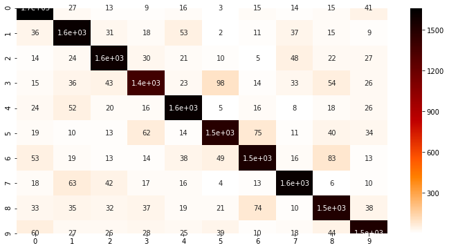

```python
# Visualize the Confusion Matrix
plt.figure(figsize=(12,6))
sns.heatmap(confusion_matrix(y_test_o, predictions), annot=True, cmap="gist_heat_r")
```

#### Visualizing some predictions

```
Actual labels corresponding to below images: [1 7 2 9 0 9 1 8 4 4 8 9 1 4 3]
Predicted labels corresponding to below images: [0 7 2 9 0 9 1 8 1 4 8 3 1 4 3]
```

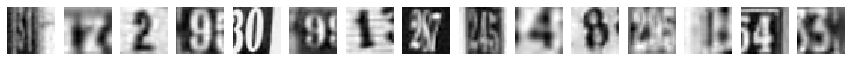

```python
# visualizing the first 15 images in the dataset and their labels
print('Actual labels corresponding to below images: %s' % (y_test_o[0:15]))
plt.figure(figsize=(15, 1))
for i in range(15):
    plt.subplot(1, 15, i+1)
    plt.imshow(X_test_o[i], cmap="gray")
    plt.axis('off')

print('Predicted labels corresponding to below images: %s' % (predictions[0:15]))
```

## Saving the Model

```python
# Set the paths to store the model and weights
model3.save('SVHN_DeepNN_model.h5')
model3.save_weights('SVHN_DeepNN_weights.h5')
```

## Inference

Deep Learning model is able to work with huge amount of data, particularly, multi - dimensional data and was able to perform better than that of traditional KNN model. It is also very fast in tearms of training and far more accurate in tearms of evaluation. Hence Deep Neural networks are always preferred over traditional machine learning algorithms when it comes to OCR.